# lab8

Zeyuan Fang

9/27/2021

upi: zfan253  
id: 556588804

## Data description

The data source for this lab is from UCI Machine Learning Repository. We are going to use the Vertebral Column data set, the description of which can be found here: https://archive.ics.uci.edu/ml/datasets/Vertebral+Column.\ The data set has 6 numeric predictors: pi (pelvic incidence), pt (pelvic tilt), lla (lumbar lordosis angle), ss (sacral slope), pr (pelvic radius), gos (grade of spondylolisthesis). The response variable is class, which has three levels: DH (Disk Hernia), SL (Spondylolisthesis), NO (Normal).

Read in data.

```r
vc = read.csv("vertebral-column.csv", stringsAsFactors=TRUE)
head(vc)
```

```
##      pi    pt   lla    ss     pr   gos class
## 1 63.03 22.55 39.61 40.48  98.67 -0.25    DH
## 2 39.06 10.06 25.02 29.00 114.41  4.56    DH
## 3 68.83 22.22 50.09 46.61 105.99 -3.53    DH
## 4 69.30 24.65 44.31 44.64 101.87 11.21    DH
## 5 49.71  9.65 28.32 40.06 108.17  7.92    DH
## 6 40.25 13.92 25.12 26.33 130.33  2.23    DH
```

To perform the following tasks, we need load the following libraries:

```r
library(MASS)
library(class)
library(gam)
library(nnet)
library(e1071)
library(parallel)
```

## Exploration

#### Q1. Create a pairwise scatterplot, with observations of different classes shown in different colors.

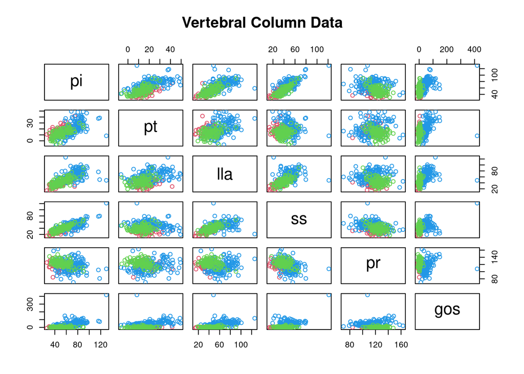

```r
#plot(vc,col=vc$class)
plot(vc[,-7], col=as.numeric(vc[,7])+1, pch=1, main="Vertebral Column Data")
```

## Classification

Five classification methods are listed in the next 5 tasks. Use each of them to build a model for the data set vc and predict the class labels of the observations that are used to build the model. For each, compute the confusion matrix and (resubstitution) classification accuracy.

#### Q2. Linear discriminant analysis.

```r
(r1 = lda(class ~. , data=vc))
```

```
## Call:
## lda(class ~ ., data = vc)
##
## Prior probabilities of groups:
##        DH        NO        SL
## 0.1935484 0.3225806 0.4838710
##
## Group means:
##          pi       pt      lla       ss       pr       gos
## DH 47.63833 17.39867 35.46350 30.24000 116.4750  2.479333
## NO 51.68560 12.82180 43.54230 38.86380 123.8912  2.187000
## SL 71.51367 20.74800 64.10987 50.76613 114.5183 51.896867
##
## Coefficients of linear discriminants:
##             LD1         LD2
## pi  -9.91610309 -1.08264029
## pt   9.90942850  1.12702599
## lla  0.04068113 -0.01475033
## ss   9.92877041  1.01520045
## pr  -0.02454498 -0.06533429
## gos  0.02298765  0.01490702
##
## Proportion of trace:
##    LD1    LD2
## 0.8612 0.1388
```

```r
p1 = predict(r1, newdata=vc)
yhat1 = p1$class
table(vc$class, yhat1)
```

```
##     yhat1
##       DH  NO  SL
##   DH  39  20   1
##   NO  12  79   9
##   SL   4  11 135
```

```r
(A1 = mean(vc$class == yhat1))
```

```
## [1] 0.816129
```

#### Q3. Quadratic discriminant analysis.

```r
(r2 = qda(class ~ ., data=vc))
```

```
## Call:
## qda(class ~ ., data = vc)
##
## Prior probabilities of groups:
##        DH        NO        SL
## 0.1935484 0.3225806 0.4838710
##
## Group means:
##          pi       pt      lla       ss       pr       gos
## DH 47.63833 17.39867 35.46350 30.24000 116.4750  2.479333
## NO 51.68560 12.82180 43.54230 38.86380 123.8912  2.187000
## SL 71.51367 20.74800 64.10987 50.76613 114.5183 51.896867
```

```r
(yhat2 = predict(r2, newdata=vc)$class)
```

```
##   [1] DH DH NO DH DH NO NO NO NO SL DH DH DH DH DH NO NO NO NO DH NO DH SL DH DH
##  [26] DH DH DH DH NO DH DH DH NO DH DH NO DH DH DH DH NO DH DH NO DH DH DH DH DH
##  [51] DH DH DH DH DH DH DH DH DH NO SL SL SL SL SL SL SL SL NO SL SL SL SL SL SL
##  [76] SL SL SL SL SL SL SL SL SL SL SL SL SL SL SL SL SL SL SL SL SL SL SL SL SL
## [101] SL SL SL SL SL DH SL SL SL SL SL SL SL SL SL SL SL SL SL SL SL SL SL SL SL
## [126] SL SL SL SL SL SL SL SL SL SL SL SL SL SL SL SL SL SL SL SL SL SL SL SL SL
## [151] SL SL SL SL SL SL SL SL SL SL SL SL SL SL SL SL SL SL SL SL SL SL SL SL SL
## [176] SL SL SL SL SL SL SL SL SL SL SL SL SL SL SL SL SL SL SL SL SL SL SL SL SL
## [201] SL SL SL SL SL SL SL SL SL SL DH NO NO NO NO NO NO NO NO DH DH NO SL SL SL
## [226] NO NO NO NO NO NO NO NO NO NO NO NO NO NO NO NO NO NO NO DH NO DH DH NO DH
## [251] NO NO NO NO NO SL NO NO NO NO NO NO NO NO NO NO NO NO NO DH NO DH DH NO NO
## [276] NO NO NO NO NO NO NO NO NO NO NO NO NO NO NO DH DH NO NO NO NO NO DH NO NO
## [301] NO NO DH NO NO NO DH NO NO NO
## Levels: DH NO SL
```

```r
table(vc$class, yhat2)
```

```
##     yhat2
##       DH  NO  SL
##   DH  42  16   2
##   NO  15  81   4
##   SL   1   1 148
```

```r
(A2=mean(vc$class==yhat2))
```

```
## [1] 0.8741935
```

#### Q4. Naive Bayes.

```r
(r3 = naiveBayes(class ~ ., data=vc))
```

```
##
## Naive Bayes Classifier for Discrete Predictors
##
## Call:
## naiveBayes.default(x = X, y = Y, laplace = laplace)
##
## A-priori probabilities:
## Y
##        DH        NO        SL
## 0.1935484 0.3225806 0.4838710
##
## Conditional probabilities:
##     pi
## Y        [,1]     [,2]
##   DH 47.63833 10.69694
##   NO 51.68560 12.36790
##   SL 71.51367 15.10908
##
##     pt
## Y        [,1]      [,2]
##   DH 17.39867  7.016809
##   NO 12.82180  6.778658
##   SL 20.74800 11.505857
##
##     lla
## Y        [,1]      [,2]
##   DH 35.46350  9.767804
##   NO 43.54230 12.361581
##   SL 64.10987 16.396336
##
##     ss
## Y        [,1]      [,2]
##   DH 30.24000  7.555102
##   NO 38.86380  9.623776
##   SL 50.76613 12.318389
##
##     pr
## Y        [,1]      [,2]
##   DH 116.4750  9.355709
##   NO 123.8912  9.013755
##   SL 114.5183 15.580436
##
##     gos
## Y         [,1]      [,2]
##   DH  2.479333  5.531449
##   NO  2.187000  6.307020
##   SL 51.896867 40.107622
```

```r
(yhat3 = predict(r3, newdata=vc))
```

```
##   [1] DH DH NO SL DH DH NO NO NO DH DH DH DH DH DH DH NO NO DH DH NO NO SL DH DH
##  [26] DH DH DH DH NO DH DH DH DH DH DH NO DH DH DH DH DH DH NO NO DH DH DH DH DH
##  [51] DH SL DH DH DH DH DH DH DH DH SL SL SL SL SL SL SL SL NO SL SL SL SL SL SL
##  [76] SL SL SL SL NO SL SL SL SL SL SL SL SL SL SL SL SL SL SL SL SL SL SL SL SL
## [101] SL SL SL SL SL NO SL SL SL SL SL SL SL SL SL NO SL SL NO SL SL SL SL SL SL
## [126] SL SL SL SL SL SL SL SL SL SL SL SL SL SL SL SL SL SL SL SL SL SL SL SL SL
## [151] SL SL SL SL SL SL SL SL SL SL SL SL SL SL SL SL SL SL SL SL SL SL SL SL SL
## [176] SL SL SL SL SL SL SL SL SL SL SL SL SL SL SL SL SL SL SL SL SL SL SL SL SL
## [201] SL SL SL SL SL SL SL SL SL SL DH NO NO NO NO NO NO NO NO DH DH NO SL SL SL
## [226] NO NO NO DH NO NO NO NO NO NO NO NO NO NO NO DH NO NO NO NO NO DH DH NO DH
## [251] NO NO NO SL SL SL NO NO NO NO NO SL DH NO NO NO NO NO NO DH NO DH DH NO DH
## [276] NO NO NO NO NO DH NO NO NO NO NO NO NO SL NO DH DH NO NO NO NO DH DH NO SL
## [301] NO SL DH NO NO DH DH NO NO NO
## Levels: DH NO SL
```

```r
table(vc$class, yhat3)
```

```
##     yhat3
##       DH  NO  SL
##   DH  45  12   3
##   NO  21  69  10
##   SL   0   5 145
```

```r
(A3=mean(vc$class==yhat3))
```

```
## [1] 0.8354839
```

#### Q5. Multinomial logistic regression.

```r
(r4 = multinom(class ~ ., data=vc))
```

```
## Call:
## multinom(formula = class ~ ., data = vc)
##
## Coefficients:
##    (Intercept)        pi         pt        lla         ss         pr
## NO   -20.23244 -4.584673   4.485069 0.03527065   4.737024 0.13049227
## SL   -21.71458 16.597946 -16.609482 0.02184513 -16.390098 0.07798643
##             gos
## NO -0.005418782
## SL  0.309521250
##
## Residual Deviance: 179.0885
## AIC: 207.0885
```

```r
(yhat4 <- predict(r4,vc))
```

```
##   [1] DH DH NO DH DH NO NO NO NO DH DH DH DH DH DH NO NO NO DH DH NO NO SL DH DH
##  [26] DH DH DH DH NO DH DH DH NO DH DH NO DH DH DH DH NO NO NO NO DH DH DH DH DH
##  [51] DH DH DH DH DH DH NO DH DH NO SL SL SL SL NO SL SL SL NO SL SL SL SL SL SL
##  [76] SL SL SL SL SL SL SL SL SL SL NO SL SL SL SL SL SL SL SL SL SL SL SL SL SL
## [101] SL SL SL SL SL DH SL SL SL SL SL SL SL SL SL SL SL SL SL SL SL SL SL SL SL
## [126] SL SL SL SL SL SL SL SL SL SL SL SL SL SL SL SL SL SL SL SL SL SL SL SL SL
## [151] SL SL SL SL SL SL SL SL SL SL SL SL SL SL SL SL SL SL SL SL SL SL SL SL SL
## [176] SL SL SL SL SL SL SL SL SL SL SL SL SL SL SL SL SL SL SL SL SL SL SL SL SL
## [201] SL SL SL SL SL SL SL SL SL SL DH NO NO NO NO NO NO NO NO DH DH NO SL NO NO
## [226] NO NO NO NO NO NO NO NO NO NO NO NO NO NO NO NO NO NO NO DH NO DH DH NO DH
## [251] NO NO NO NO NO SL NO NO NO NO NO NO NO NO NO NO NO NO NO DH NO DH NO NO NO
## [276] NO NO NO NO NO NO NO NO NO NO NO NO NO NO NO DH NO NO NO NO NO NO DH NO NO
## [301] NO NO DH NO NO NO DH NO NO NO
## Levels: DH NO SL
```

```r
table(vc$class, yhat4)
```

```
##     yhat4
##       DH  NO  SL
##   DH  40  19   1
##   NO  13  85   2
##   SL   1   3 146
```

```r
(A4= mean(vc$class==yhat4))
```

```
## [1] 0.8741935
```

#### Q6. K-nearest neighbours (with K=10).

```r
set.seed(769)
(yhat5 = knn(train=vc[,1:6], test=vc[,1:6], cl=vc[,7], k=10))   # K = 10
```

```
##   [1] DH DH DH DH DH NO DH DH DH DH DH DH DH DH DH NO DH NO DH DH NO DH SL DH DH
##  [26] DH DH DH DH NO NO DH DH NO DH DH NO NO DH NO DH NO DH NO NO DH DH DH DH DH
##  [51] NO DH DH DH DH DH DH NO NO NO SL SL SL SL SL SL SL SL NO SL SL SL SL SL SL
##  [76] SL SL SL SL SL SL SL SL SL SL NO SL SL SL SL SL SL SL SL SL SL SL SL SL SL
## [101] SL SL SL SL SL DH SL SL SL SL SL SL SL SL SL SL SL SL NO SL SL SL SL SL SL
## [126] SL SL SL SL SL SL SL SL SL SL SL SL SL SL SL SL SL SL SL SL SL SL SL SL SL
## [151] SL SL SL SL SL SL SL SL SL SL SL SL SL SL SL SL SL SL SL SL SL SL SL SL SL
## [176] SL SL SL SL SL SL SL SL SL SL SL SL SL SL SL SL SL SL SL SL SL SL SL SL SL
## [201] SL SL SL SL SL SL SL SL SL SL DH NO NO NO NO DH NO NO NO DH DH NO SL NO SL
## [226] NO NO NO NO NO NO NO NO NO NO NO NO NO NO NO NO NO NO NO DH NO DH NO NO DH
## [251] NO NO NO NO NO SL NO NO NO NO NO NO NO NO NO NO NO NO NO NO NO DH NO NO NO
## [276] NO NO NO NO NO DH NO NO NO NO NO NO NO NO NO NO DH NO NO NO NO NO DH NO NO
## [301] NO NO DH NO NO NO NO NO NO NO
## Levels: DH NO SL
```

```r
table(vc[,7], yhat5)
```

```
##     yhat5
##       DH  NO  SL
##   DH  42  17   1
##   NO  12  85   3
##   SL   1   3 146
```

```r
(A5= mean(vc[,7]==yhat5))
```

```
## [1] 0.8806452
```

## Primary Performance Evaluation

#### Q7. Present your resulting classification accuracy for all five classification methods in a table (in whatever format). From this table, what can we say about the relative performance of these methods for the data set?

```r
res <- c("LDA"=A1,"QDA"=A2,"NB"=A3,"MultLogReg"=A4,"KNN"=A5)
sort(res)
```

```
##        LDA         NB        QDA MultLogReg        KNN
##  0.8161290  0.8354839  0.8741935  0.8741935  0.8806452
```

## Multiple Logistic Regression and Generalised Additive Models

#### Q8. Create a response variable from variable class so that both classes DH and SL are relabelled as AB (Abnormal). Use glm() to build a multiple logistic regression model for this new class variable, and compute the confusion matrix and resubstitution classification accuracy.

```r
(vc$bi_class <- factor(ifelse(vc$class=="SL" | vc$class=="DH","AB","NO")))
```

```
##   [1] AB AB AB AB AB AB AB AB AB AB AB AB AB AB AB AB AB AB AB AB AB AB AB AB AB
##  [26] AB AB AB AB AB AB AB AB AB AB AB AB AB AB AB AB AB AB AB AB AB AB AB AB AB
##  [51] AB AB AB AB AB AB AB AB AB AB AB AB AB AB AB AB AB AB AB AB AB AB AB AB AB
##  [76] AB AB AB AB AB AB AB AB AB AB AB AB AB AB AB AB AB AB AB AB AB AB AB AB AB
## [101] AB AB AB AB AB AB AB AB AB AB AB AB AB AB AB AB AB AB AB AB AB AB AB AB AB
## [126] AB AB AB AB AB AB AB AB AB AB AB AB AB AB AB AB AB AB AB AB AB AB AB AB AB
## [151] AB AB AB AB AB AB AB AB AB AB AB AB AB AB AB AB AB AB AB AB AB AB AB AB AB
## [176] AB AB AB AB AB AB AB AB AB AB AB AB AB AB AB AB AB AB AB AB AB AB AB AB AB
## [201] AB AB AB AB AB AB AB AB AB AB NO NO NO NO NO NO NO NO NO NO NO NO NO NO NO
## [226] NO NO NO NO NO NO NO NO NO NO NO NO NO NO NO NO NO NO NO NO NO NO NO NO NO
## [251] NO NO NO NO NO NO NO NO NO NO NO NO NO NO NO NO NO NO NO NO NO NO NO NO NO
## [276] NO NO NO NO NO NO NO NO NO NO NO NO NO NO NO NO NO NO NO NO NO NO NO NO NO
## [301] NO NO NO NO NO NO NO NO NO NO
## Levels: AB NO
```

```r
(r6 = glm(bi_class ~.-class, data=vc, family=binomial))
```

```
##
## Call:  glm(formula = bi_class ~ . - class, family = binomial, data = vc)
##
## Coefficients:
## (Intercept)           pi           pt          lla           ss           pr
##   -15.14270     12.88787    -12.96465      0.01939    -12.79191      0.10684
##         gos
##    -0.16794
##
## Degrees of Freedom: 309 Total (i.e. Null);  303 Residual
## Null Deviance:       389.9
## Residual Deviance: 178.1     AIC: 192.1
```

```r
p6<-predict(r6,vc,type="response")
yhat6 <-as.numeric(p6>0.5)+1
table(vc$bi_class,levels(vc$bi_class)[yhat6])
```

```
##
##       AB  NO
##   AB 188  22
##   NO  22  78
```

```r
mean(vc$bi_class == levels(vc$bi_class)[yhat6])
```

```
## [1] 0.8580645
```

The accuracy does not improve though the response variable now only has two levels.( from 87% to 85%)

#### Q9. Use step() to find the AIC-selected model, with backward selection. Which variables are removed by the AIC?

```r
r7 <- step(r6,type="backward")
```

```
## Start:  AIC=192.13
## bi_class ~ (pi + pt + lla + ss + pr + gos + class) - class
##
##        Df Deviance    AIC
## - ss    1   178.27 190.27
## - pi    1   178.27 190.27
## - pt    1   178.27 190.27
## - lla   1   178.86 190.86
## <none>      178.13 192.13
## - pr    1   209.31 221.31
## - gos   1   302.31 314.31
##
## Step:  AIC=190.27
## bi_class ~ pi + pt + lla + pr + gos
##
##        Df Deviance    AIC
## - lla   1   178.95 188.95
## <none>      178.27 190.27
## - pi    1   189.08 199.08
## - pt    1   202.23 212.23
## - pr    1   209.36 219.36
## - gos   1   303.45 313.45
##
## Step:  AIC=188.95
## bi_class ~ pi + pt + pr + gos
##
##        Df Deviance    AIC
## <none>      178.95 188.95
## - pt    1   208.55 216.55
## - pr    1   212.18 220.18
## - pi    1   212.53 220.53
## - gos   1   310.54 318.53
```

```r
summary(r7)
```

```
##
## Call:
## glm(formula = bi_class ~ pi + pt + pr + gos, family = binomial,
##     data = vc)
##
## Deviance Residuals:
##      Min        1Q    Median        3Q       Max
## -2.21933  -0.37927  -0.03193   0.40184   2.79266
##
## Coefficients:
##              Estimate Std. Error z value Pr(>|z|)
## (Intercept) -15.45723    3.27273  -4.723 2.32e-06 ***
## pi            0.11495    0.02266   5.072 3.94e-07 ***
## pt           -0.18140    0.03784  -4.794 1.63e-06 ***
## pr            0.10895    0.02279   4.780 1.75e-06 ***
## gos          -0.16538    0.02288  -7.227 4.92e-13 ***
## ---
## Signif. codes:  0 '***' 0.001 '**' 0.01 '*' 0.05 '.' 0.1 ' ' 1
##
## (Dispersion parameter for binomial family taken to be 1)
##
##     Null deviance: 389.86  on 309  degrees of freedom
## Residual deviance: 178.95  on 305  degrees of freedom
## AIC: 188.95
##
## Number of Fisher Scoring iterations: 8
```

lla, ss are removed by the AIC.

#### Q10. Extend the AIC-selected model with gam() so that each linear term is replaced with a smoothing spline of 5 degrees of freedom. Take a visual approach to reasonably lower the degrees of freedom in each term. For your chosen model, compute the confusion matrix and classification accuracy.

```r
r8 <- gam(bi_class ~ s(pi,5) + s(pt,5) + s(pr,5) + s(gos,5) ,data=vc, family=binomial())
```

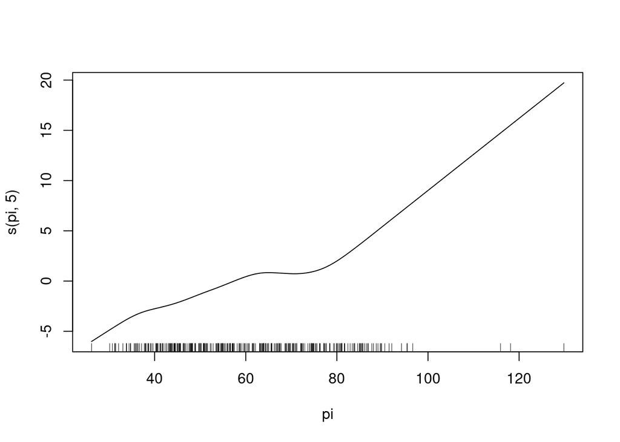

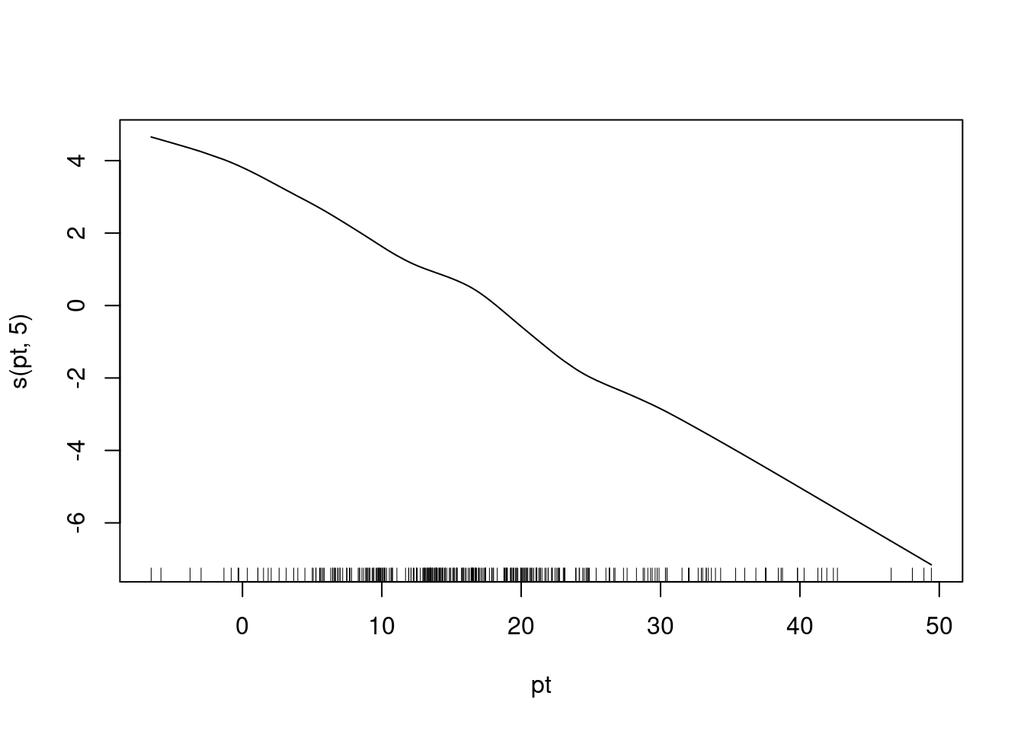

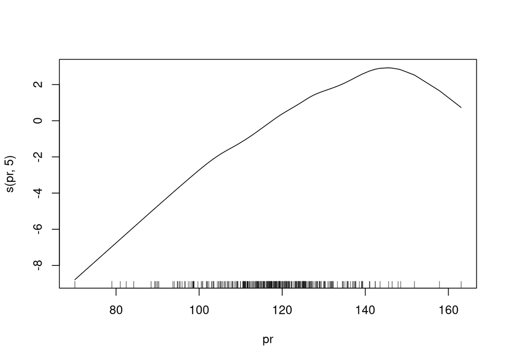

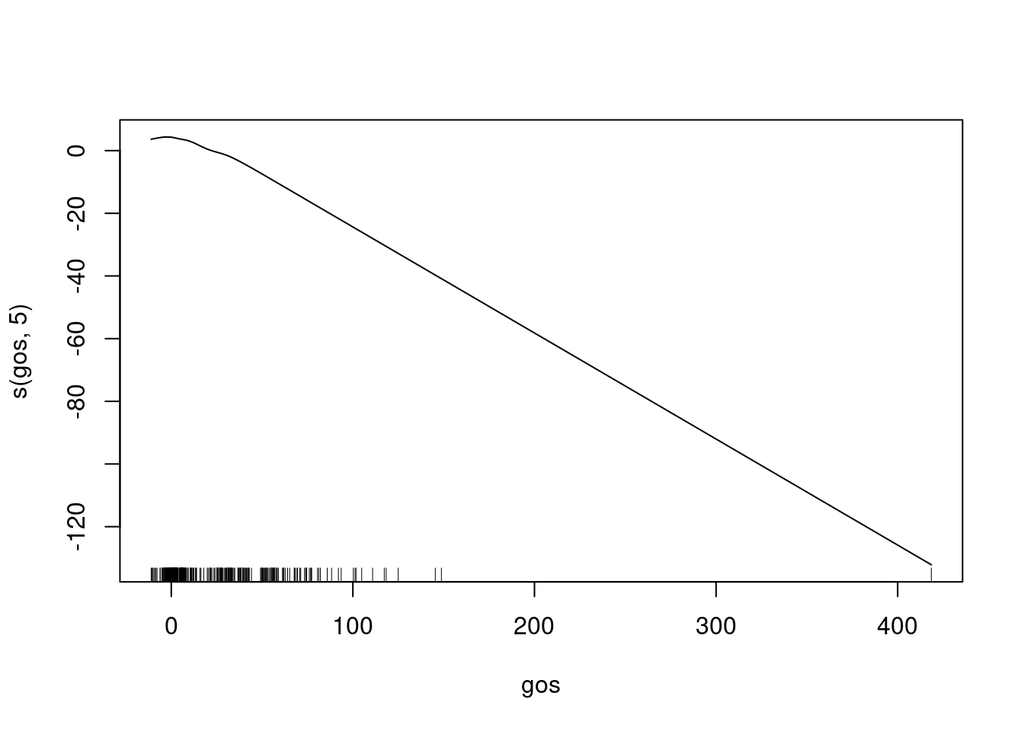

```r
plot(r8)
```

```r
r9 <- gam(bi_class ~ pi + pt + s(pr,2) + gos ,data=vc, family=binomial())
```

```r
p9 <- predict(r9,vc,type = "response")
yhat9 <-as.numeric(p9>0.5)+1
table(vc$bi_class,levels(vc$bi_class)[yhat9])
```

```
##
##       AB  NO
##   AB 186  24
##   NO  18  82
```

```r
(A9= mean(vc$bi_class ==levels(vc$bi_class)[yhat9]))
```

```
## [1] 0.8645161
```

## Cross-validation and Parallel Computing

#### Q11. Reconsider the 3-class problem studied in Questions 2-7. Use 10 repetitions of 10-fold cross-validation to evaluate the performance of the 5 classification methods.Present your resulting classification accuracy of all five classification methods in a table. Comment on the results.

remove 2-class label.

```r
vc = vc[,-8]
```

```r
n=nrow(vc)

R = 10                   # number of repetitions
K = 10
accuracy = matrix(nrow=R*K, ncol=5)
test.set = function(i, n, K=10) {
  if(i < 1 || i > K)
    stop(" i out of range (1, K)")
  start = round(1 + (i-1) * n / K)
  end = ifelse(i == K, n, round(i * n / K))
  start:end
}

set.seed(769)
for(i in 1:R) {                  # for each repetition
  ind = sample(n)
  for(k in 1:K) {                # for each fold
    index = ind[test.set(k, n, K)]
    test = vc[index,]
    train = vc[-index,]
    r1 = lda(class ~. , data=train)
    accuracy[K*(i-1)+k,1] = mean(test$class ==predict(r1,newdata = test)$class)
    r2 = qda(class ~ ., data=train)
    accuracy[K*(i-1)+k,2] = mean(test$class ==predict(r2,newdata = test)$class)
    r3 = naiveBayes(class ~ ., data=train)
    accuracy[K*(i-1)+k,3] = mean(test$class==predict(r3,newdata = test))
    r4 = multinom(class ~ ., data=train,trace= F)
    accuracy[K*(i-1)+k,4] = mean(test$class == predict(r4,newdata = test))
    accuracy[K*(i-1)+k,5] =mean(test$class ==knn(train=train[,1:6], test=test[,1:6], cl=train[,7], k=10))

  }
}
```

```r
cv_res <-data.frame( classifier=  c("LDA","QDA","NB","MultLogReg","KNN"), accuracy= colMeans(accuracy) )
cv_res[order(-cv_res$accuracy),]
```

```
##   classifier  accuracy
## 4 MultLogReg 0.8580645
## 2        QDA 0.8409677
## 5        KNN 0.8351613
## 3         NB 0.8206452
## 1        LDA 0.8096774
```

#### Q12. Modify your code so that parallel computing can be used, in which each job running in parallel is only for the computation about one fold out of 10 (i.e., one training set and one test set). Make sure that the same subsamples are used by different methods and that the results are reproducible. Compare timings with 1, 5, 10, 20 cores

```r
n=nrow(vc)
R = 10                   # number of repetitions
K = 10

test.set = function(i, n, K=10) {
  if(i < 1 || i > K)
    stop(" i out of range (1, K)")
  start = round(1 + (i-1) * n / K)
  end = ifelse(i == K, n, round(i * n / K))
  start:end
}
set.seed(769)
cv <- list()
for(i in 1:K) {                  # for each repetition
    cv[[K]] <- list()
    ind = sample(n)
    for(k in 1:R) {                # for each fold
      index = ind[test.set(k, n, K)]
      cv[[i]][[k]] <- index
  }
}
```

```r
lapply(c(1,5,10,20),function(nc){
  system.time({
  cv_res = c(cv_res, mclapply(1:10,function(k){
    accuracy = matrix(nrow=R,ncol = 5)
    for(i in 1:R){
      test = vc[cv[[i]][[k]],]
      train =vc[-cv[[i]][[k]],]
      r1 = lda(class ~. , data=train)
      accuracy[i,1] = mean(test$class ==predict(r1,newdata = test)$class)
      r2 = qda(class ~ ., data=train)
      accuracy[i,2] = mean(test$class ==predict(r2,newdata = test)$class)
      r3 = naiveBayes(class ~ ., data=train)
      accuracy[i,3] = mean(test$class==predict(r3,newdata = test))
      r4 = multinom(class ~ ., data=train,trace=F)
      accuracy[i,4] = mean(test$class == predict(r4,newdata = test))
      accuracy[i,5] =mean(test$class ==knn(train=train[,1:6], test=test[,1:6], cl=train[,7], k=10))
    }
    return(accuracy)
  },mc.cores = nc))
  })
})
```

```
## [[1]]
##    user  system elapsed
##   2.723   0.000   2.723
##
## [[2]]
##    user  system elapsed
##   1.634   0.136   0.924
##
## [[3]]
##    user  system elapsed
##   2.857   0.388   0.498
##
## [[4]]
##    user  system elapsed
##   3.267   0.452   0.494
```

```r
res <- lapply(c(1,5,10,20),function(nc){
  cv_res = c(cv_res, mclapply(1:10,function(k){
    accuracy = data.frame(matrix(nrow=R,ncol = 5))
    for(i in 1:R){
      test = vc[cv[[i]][[k]],]
      train =vc[-cv[[i]][[k]],]
      r1 = lda(class ~. , data=train)
      accuracy[i,1] = mean(test$class ==predict(r1,newdata = test)$class)
      r2 = qda(class ~ ., data=train)
      accuracy[i,2] = mean(test$class ==predict(r2,newdata = test)$class)
      r3 = naiveBayes(class ~ ., data=train)
      accuracy[i,3] = mean(test$class==predict(r3,newdata = test))
      r4 = multinom(class ~ ., data=train,trace=F)
      accuracy[i,4] = mean(test$class == predict(r4,newdata = test))
      accuracy[i,5] =mean(test$class ==knn(train=train[,1:6], test=test[,1:6], cl=train[,7], k=10))
    }
    return(accuracy)
  },mc.cores = nc))
  return(cv_res)
})
for(nc in res ){
  nc <- nc[c(-1,-2)]
  cv_res <- do.call(rbind.data.frame,nc)
  #cv_res <- as.data.frame(sapply(cv_res[,1:5],as.numeric))
  #cv_res <- cv_res[complete.cases(cv_res),]
  #print(nc)

  cv_res <-data.frame( classifier=  c("LDA","QDA","NB","MultLogReg","KNN"), accuracy= colMeans(cv_res) )
  print(cv_res[order(-cv_res$accuracy),])
}
```

```
##    classifier  accuracy
## X4 MultLogReg 0.8596774
## X2        QDA 0.8396774
## X5        KNN 0.8325806
## X3         NB 0.8241935
## X1        LDA 0.8074194
##    classifier  accuracy
## X4 MultLogReg 0.8596774
## X2        QDA 0.8396774
## X5        KNN 0.8309677
## X3         NB 0.8241935
## X1        LDA 0.8074194
##    classifier  accuracy
## X4 MultLogReg 0.8596774
## X2        QDA 0.8396774
## X5        KNN 0.8312903
## X3         NB 0.8241935
## X1        LDA 0.8074194
##    classifier  accuracy
## X4 MultLogReg 0.8596774
## X2        QDA 0.8396774
## X5        KNN 0.8267742
## X3         NB 0.8241935
## X1        LDA 0.8074194
```